# Social Network Analysis (SNA) Part2

Nik Bear Brown

In this lesson we’ll learn the how to implement and analyze Social network analysis (SNA) in R.

# Additional packages needed

To run the code you may need additional packages.

- If necessary install the followings packages.

`install.packages("igraph");`  
`install.packages("tools");`  
`install.packages("visNetwork");`

```r
library(igraph)
library(tools)
library(visNetwork)
```

# Data

We will be creating graphs with the library(igraph).

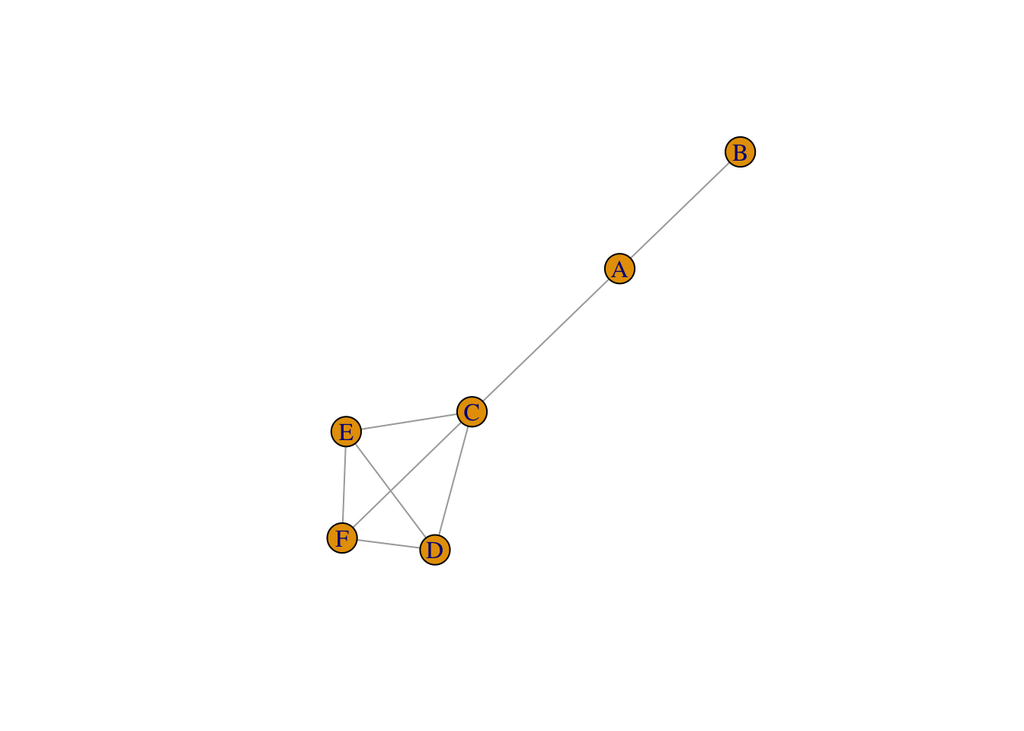

```r
# for reproducibility of graphs plots (plot.igraph uses random numbers)
set.seed(3333)
# create an example graph
D <- read.table(header=T,text=
                  'from to
A B
A C
C D
C F
C E
D E
D F
E F')
g1 <- graph.data.frame(D,directed=F)
# plot the original graph
plot(g1)
```

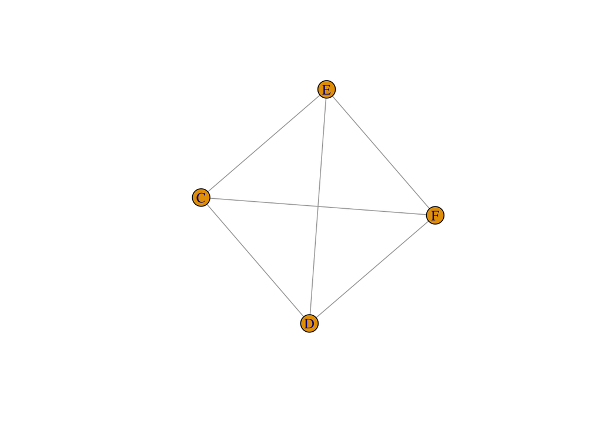

```r
# find all the largest cliques (returns a list of vector of vertiex ids)
a <- largest.cliques(g1)
# let's just take the first of the largest cliques
# (in this case there's just one clique)
clique1 <- a[[1]]
# subset the original graph by passing the clique vertices
g2 <- graph.full(length(clique1))
V(g2)$name <- V(g1)$name[clique1]
# plot the clique
plot(g2)
```

In addition we will be using social relations among Renaissance Florentine families (person aggregates) collected by John Padgett from historical documents. The two relations are business ties (PADGB - specifically, recorded financial ties such as loans, credits and joint partnerships) and marriage alliances (PADGM). See http://moreno.ss.uci.edu/data.html#padgett

```r
# Studying marriage ties among Renaissance Florentine families
data_url <- 'http://nikbearbrown.com/YouTube/MachineLearning/M12/padgett-cleaned.txt'
padgett.cleaned <- read.table(url(data_url), quote="\"")
```

# Cliques and Motifs among Renaissance Florentine families

Find and plot all the largest cliques seperately. Find any significant motifs.

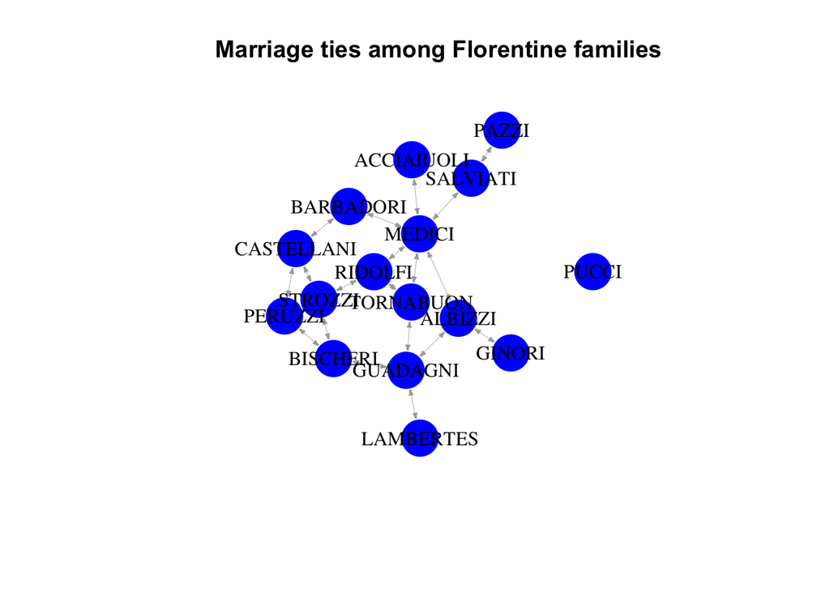

```r
florentine_marriage_ties <- padgett.cleaned[1:16,]
rownames(florentine_marriage_ties) <- c("ACCIAIUOLI", "ALBIZZI", "BARBADORI",
                                        "BISCHERI", "CASTELLANI", "GINORI",
                                        "GUADAGNI", "LAMBERTES","MEDICI",
                                        "PAZZI", "PERUZZI", "PUCCI",
                                        "RIDOLFI", "SALVIATI", "STROZZI",
                                        "TORNABUON")
colnames(florentine_marriage_ties) <- rownames(florentine_marriage_ties)
florentine_graph <-
  graph_from_adjacency_matrix(as.matrix(florentine_marriage_ties))
plot(florentine_graph, layout=layout.fruchterman.reingold,
     main = "Marriage ties among Florentine families",
     vertex.label=V(florentine_graph)$name, vertex.size=25,
     vertex.color="blue", vertex.frame.color="white",
     vertex.label.color="black", vertex.label.cex=1,
     edge.arrow.size=0.25, edge.width=0.25)
```

```r
count_motifs(florentine_graph, size = 3)
```

```
## [1] 41
```

```r
count_motifs(florentine_graph, size = 4)
```

```
## [1] 91
```

```r
# find and plot all the largest cliques seperately
florentine_graph_undirected <- as.undirected(florentine_graph)
# following code taken from
# http://stackoverflow.com/questions/26222659/identifying-cliques-in-r
all <- largest_cliques(florentine_graph_undirected)
all
```

```
## [[1]]
## + 3/16 vertices, named:
## [1] STROZZI    PERUZZI    CASTELLANI
##
## [[2]]
## + 3/16 vertices, named:
## [1] STROZZI  PERUZZI  BISCHERI
##
## [[3]]
## + 3/16 vertices, named:
## [1] MEDICI    RIDOLFI   TORNABUON
```

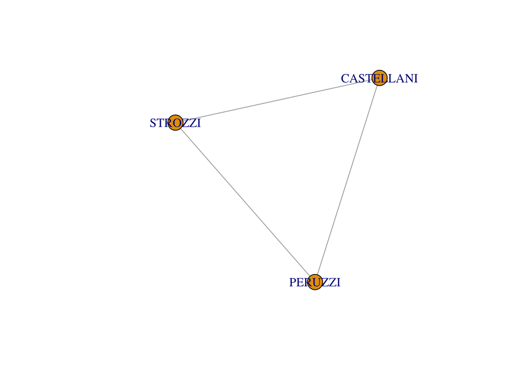

```r
clique_graph1 <- make_full_graph(length(all[[1]]))
V(clique_graph1)$name <- V(florentine_graph_undirected)$name[all[[1]]]
plot(clique_graph1)
```

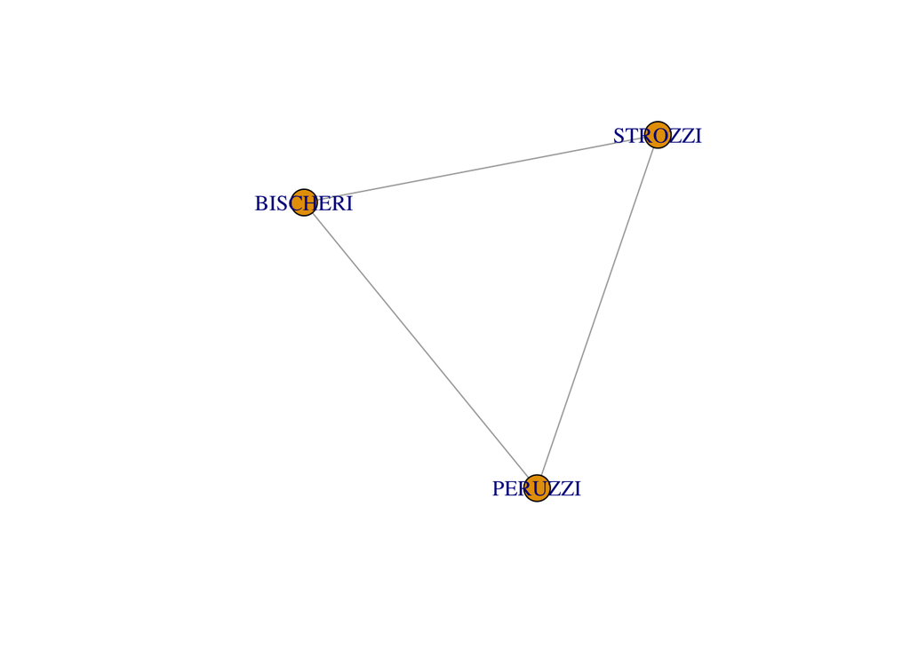

```r
clique_graph2 <- make_full_graph(length(all[[2]]))
V(clique_graph2)$name <- V(florentine_graph_undirected)$name[all[[2]]]
plot(clique_graph2)
```

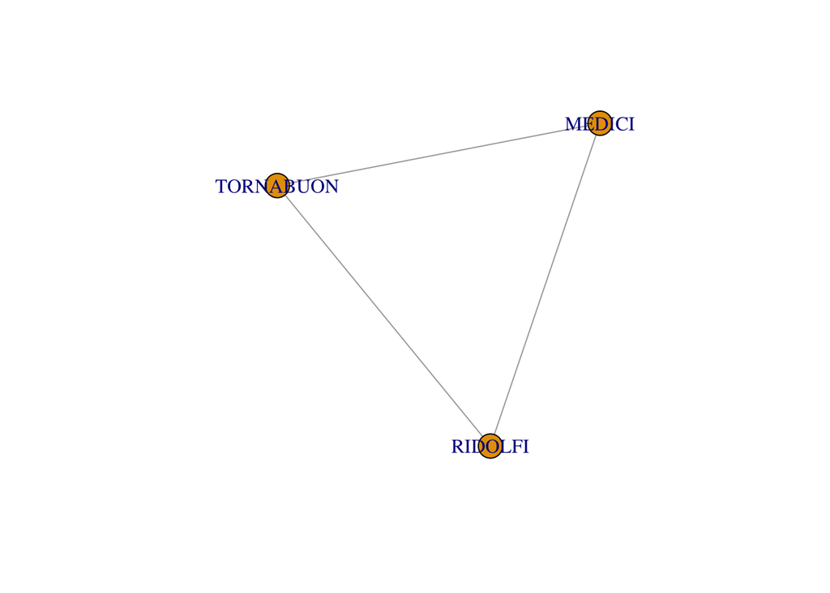

```r
clique_graph3 <- make_full_graph(length(all[[3]]))
V(clique_graph3)$name <- V(florentine_graph_undirected)$name[all[[3]]]
plot(clique_graph3)
```

```r
# plot all largest cliques
# following code taken from R and Data Mining: Examples and Case Studies
# by Yanchang Zhao, page 118
florentine_largest_cliques <- largest_cliques(florentine_graph_undirected)
length(florentine_largest_cliques)
```

```
## [1] 3
```

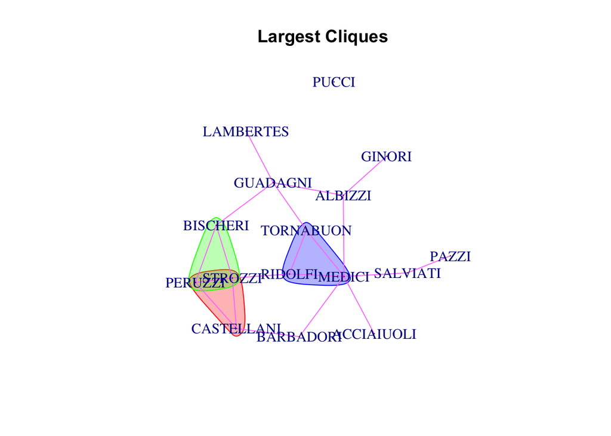

```r
colorbar <- rainbow(length(florentine_largest_cliques) + 1)
for (i in 1:length(florentine_largest_cliques)) {
  V(florentine_graph_undirected)[florentine_largest_cliques[[i]]]$color <- colorbar[i+1]
}
plot(florentine_graph_undirected, mark.groups=florentine_largest_cliques,
     vertex.size=0.3, vertex.label.cex=1, edge.color=rgb(1,0.5,1,1),
     main = "Largest Cliques")
```

```r
# plot all maximal cliques
# following code taken from R and Data Mining: Examples and Case Studies
# by Yanchang Zhao, page 117
florentine_max_cliques <- max_cliques(florentine_graph_undirected)
length(florentine_max_cliques)
```

```
## [1] 16
```

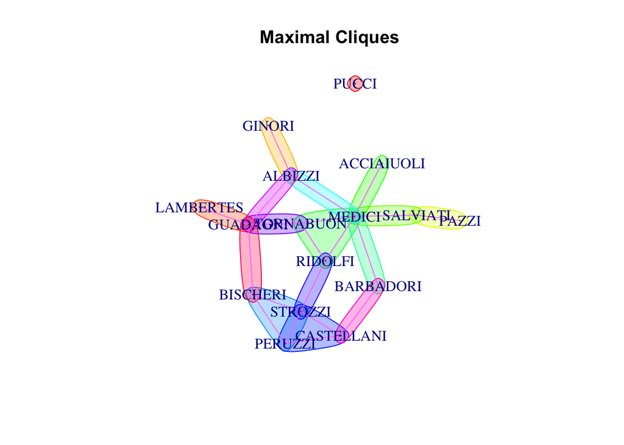

```r
colorbar <- rainbow(length(florentine_max_cliques) + 1)
for (i in 1:length(florentine_max_cliques)) {
  V(florentine_graph_undirected)[florentine_max_cliques[[i]]]$color <- colorbar[i+1]
}
plot(florentine_graph_undirected, mark.groups=florentine_max_cliques,
     vertex.size=0.3, vertex.label.cex=1, edge.color=rgb(1,0.5,1,1),
     main = "Maximal Cliques")
```

```r
# Calculate PageRank of the vertices
ranks_of_families <- page_rank(florentine_graph)$vector
ranks_of_families
```

```
## ACCIAIUOLI    ALBIZZI  BARBADORI   BISCHERI CASTELLANI     GINORI
## 0.03035390 0.07833886 0.04980296 0.06818000 0.06864374 0.03209700
##   GUADAGNI  LAMBERTES     MEDICI      PAZZI    PERUZZI      PUCCI
## 0.09742360 0.03060350 0.14437347 0.03569690 0.06720328 0.00990099
##    RIDOLFI   SALVIATI    STROZZI  TORNABUON
## 0.06888541 0.06069627 0.08722618 0.07057395
```

```r
# most important or influential family
which.max(ranks_of_families) # 9 is the index of the vertex
```

```
## MEDICI
##      9
```

# Resources

- [Network visualization in R with the igraph package](https://rulesofreason.wordpress.com/2012/11/05/network-visualization-in-r-with-the-igraph-package/)
- [Making prettier network graphs with sna and igraph via @rbloggers](http://www.r-bloggers.com/making-prettier-network-graphs-with-sna-and-igraph/)
- [igraph R manual pages](http://igraph.org/r/doc/)

# References

The data, R code and lessons are based upon:

Graph theory/data structures:  
* http://math.tut.fi/~ruohonen/GT_English.pdf  
* http://www.cl.cam.ac.uk/teaching/1011/PrincComm/slides-lpr/graph_theory_1-11.pdf  
* http://www.researchgate.net/publication/228300013_Graph_Theory_A_Primer_for_Using_R_Visualization_Techniques_in_the_Applications_of_the_Adjacency_Matrix  
* http://www.boost.org/doc/libs/1_59_0/libs/graph/doc/graph_theory_review.html  
SNA:  
* http://files.meetup.com/1406240/sna_in_R.pdf  
* http://www2.unb.ca/~ddu/6634/Lecture_notes/Lec1_intro_handout.pdf  
* http://www.faculty.ucr.edu/~hanneman/nettext/  
* http://citeseerx.ist.psu.edu/viewdoc/download?doi=10.1.1.372.1960&rep=rep1&type=pdf  
* http://www.rdatamining.com/examples/social-network-analysis

igraph:  
* http://statmath.wu.ac.at/research/friday/resources_WS0708_SS08/igraph.pdf  
* http://blog.revolutionanalytics.com/2014/11/a-look-at-the-igraph-package.html  
* http://www.r-bloggers.com/igraph-and-sna-an-amateurs-dabbling/  
* http://www.r-bloggers.com/going-viral-with-rs-igraph-package/  
* https://cran.r-project.org/web/packages/igraph/igraph.pdf

Other famous packages for SNA:  
* http://www.r-bloggers.com/must-have-r-packages-for-social-scientists/  
* https://cran.r-project.org/web/views/SocialSciences.html  
* https://cran.r-project.org/web/packages/sna/sna.pdf  
* https://cran.r-project.org/web/packages/RSiena/RSiena.pdf  
* https://cran.r-project.org/web/packages/network/network.pdf  
* https://www.bioconductor.org/packages/release/bioc/manuals/graph/man/graph.pdf  
* http://www.statnet.org/

In-depth SNA tutorials:  
* http://sna.stanford.edu/rlabs.php  
* http://www.stats.ox.ac.uk/~snijders/sna_course.htm  
* http://www.shizukalab.com/toolkits

Sample projects:

- http://www.orgnet.com/cases.html

Motifs:  
* http://igraph.org/r/doc/motifs.html  
* https://en.wikipedia.org/wiki/Network_motif  
* http://www.cs.columbia.edu/4761/notes07/chapter8.2-topology.pdf  
* https://sites.google.com/site/networkanalysisacourse/schedule/networkmotifs  
Cliques:  
* http://igraph.org/r/doc/cliques.html  
* http://faculty.ucr.edu/~hanneman/nettext/C11_Cliques.html  
* https://courses.cs.washington.edu/courses/cse527/01au/oct25/oct25.html  
* ttp://www.mathcove.net/petersen/lessons/get-lesson?les=29  
* http://news.stanford.edu/news/2014/november/cliques-high-school-110514.html  
PageRank:  
* http://igraph.org/r/doc/page_rank.html  
* http://ilpubs.stanford.edu:8090/422/1/1999-66.pdf  
* http://www.cs.princeton.edu/~chazelle/courses/BIB/pagerank.htm  
* http://www.stat.cmu.edu/~ryantibs/datamining/lectures/03-pr-marked.pdf  
* http://smallstats.blogspot.com/2014/04/from-random-walks-to-personalized.html  
* http://blog.revolutionanalytics.com/2014/12/a-reproducible-r-example-finding-the-most-popular-packages-using-the-pagerank-algorithm.html  
* Mining Massive Datasets on Coursera - Week 1, Videos 5 through 11 explain PageRank elegantly. The course maybe unavailable (or archived) by the time this module is out

Dataset:  
* http://moreno.ss.uci.edu/data.html#padgett  
* http://home.uchicago.edu/~jpadgett/papers/unpublished/maelite.pdf

Other SNA:  
* http://www.r-bloggers.com/experiments-with-igraph/  
* http://cran.us.r-project.org/doc/contrib/Zhao_R_and_data_mining.pdf